# EasyVisa Project

## **Building bagging and boosting models**

**Model evaluation criterion**

We will make wrong prediction in 2 ways

1) It will be predicting applicants visa will get certified but in reality it should get denied. In this case job will be given to a wrong applicant and suitable applicant will miss the opportunity and it is a loss for the USA.

2) It will be predicting applicants visa will get denied but in reality it should get approved. In this case USA will loose suitable applicant who really can help to the country to build economy.

I think both the case will be important to us so

We want to maximize F1 score as FN and FP both are imporant in our case.

**Build Decision Tree Model**

```python
dTree = DecisionTreeClassifier(criterion = 'gini', random_state=1)
dTree.fit(X_train, y_train)
```

```
DecisionTreeClassifier(random_state=1)
```

```
The precision score is 1.000
The recall score is 1.000
The accuracy score is 1.000
The F1 score is 1.000
```

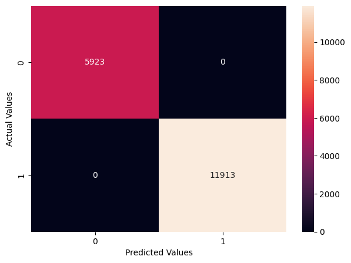

```
Result for the Training model are:
```

|  | Recall | Precesion | Accuracy | F1_score |
| --- | --- | --- | --- | --- |
| 0 | 1.0 | 1.0 | 1.0 | 1.0 |

```python
# Evaluating training model performance
decisiontree_train_perf = score(dTree,X_train,y_train,'Training')
decisiontree_train_perf
```

```
The precision score is 0.749
The recall score is 0.739
The accuracy score is 0.660
The F1 score is 0.744
```

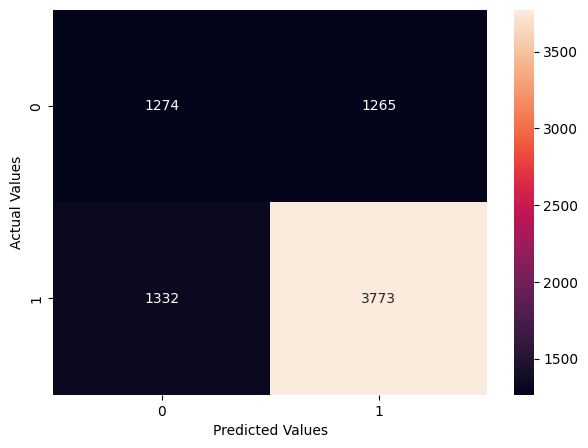

```
Result for the Testing model are:
```

|  | Recall | Precesion | Accuracy | F1_score |
| --- | --- | --- | --- | --- |
| 0 | 0.739079 | 0.748908 | 0.660256 | 0.743961 |

```python
# Evaluating testing model performance
decisiontree_test_perf = score(dTree,X_test,y_test,'Testing')
decisiontree_test_perf
```

**Using Hyper Tuning on DecisionTree model**

```python
# Choose the type of classifier.
dTree_estimator = DecisionTreeClassifier(random_state=1, class_weight="balanced")

# Grid of parameters to choose from
parameters = {
    'max_depth': np.arange(2,6),
    'min_samples_leaf': [1, 4, 7],
    'max_leaf_nodes' : [10, 15],
    'min_impurity_decrease': [0.0001,0.001]
}

# Type of scoring used to compare parameter combinations
acc_scorer = make_scorer(f1_score)

# Run the grid search
grid_obj = GridSearchCV(dTree_estimator, parameters, scoring=acc_scorer, cv=5)
grid_obj = grid_obj.fit(X_train, y_train)

# Set the clf to the best combination of parameters
dTree_estimator = grid_obj.best_estimator_

# Fit the best algorithm to the data.
dTree_estimator.fit(X_train, y_train)
```

```
DecisionTreeClassifier(class_weight='balanced', max_depth=4, max_leaf_nodes=15,
                       min_impurity_decrease=0.001, random_state=1)
```

```
The precision score is 0.793
The recall score is 0.778
The accuracy score is 0.716
The F1 score is 0.786
```

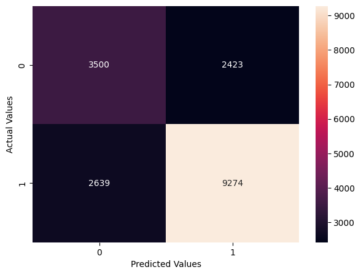

```
Result for the Training model are:
```

|  | Recall | Precesion | Accuracy | F1_score |
| --- | --- | --- | --- | --- |
| 0 | 0.778477 | 0.792853 | 0.716192 | 0.785599 |

```python
# Evaluating training model performance
decisiontree_Hypertuned_train_perf = score(dTree_estimator,X_train,y_train,'Training')
decisiontree_Hypertuned_train_perf
```

```
The precision score is 0.790
The recall score is 0.781
The accuracy score is 0.715
The F1 score is 0.785
```

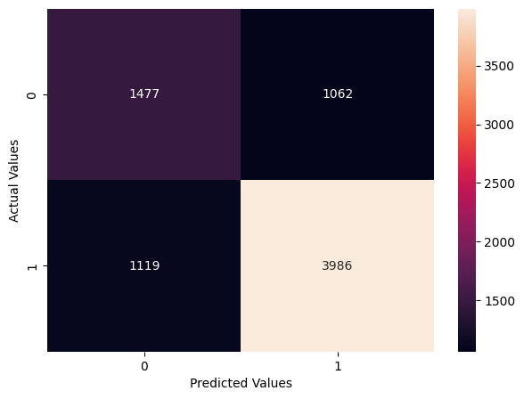

```
Result for the Testing model are:
```

|  | Recall | Precesion | Accuracy | F1_score |
| --- | --- | --- | --- | --- |
| 0 | 0.780803 | 0.78962 | 0.714678 | 0.785187 |

```python
# Evaluating testing model performance
decisiontree_Hypertuned_test_perf = score(dTree_estimator,X_test,y_test,'Testing')
decisiontree_Hypertuned_test_perf
```

**Bagging - Model Building**

```python
#base_estimator for bagging classifier is a decision tree by default
bagging_estimator=BaggingClassifier(random_state=1)
bagging_estimator.fit(X_train,y_train)
```

```
BaggingClassifier(random_state=1)
```

```
The precision score is 0.990
The recall score is 0.985
The accuracy score is 0.984
The F1 score is 0.988
```

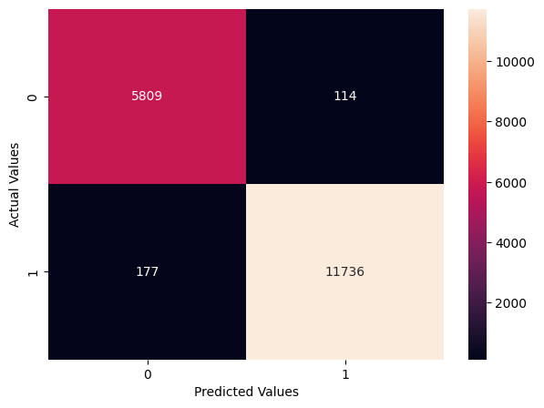

```
Result for the Training model are:
```

|  | Recall | Precesion | Accuracy | F1_score |
| --- | --- | --- | --- | --- |
| 0 | 0.985142 | 0.99038 | 0.983685 | 0.987754 |

```python
# Evaluating training model performance
bagging_estimator_train_perf = score(bagging_estimator,X_train,y_train,'Training')
bagging_estimator_train_perf
```

```
The precision score is 0.772
The recall score is 0.766
The accuracy score is 0.693
The F1 score is 0.769
```

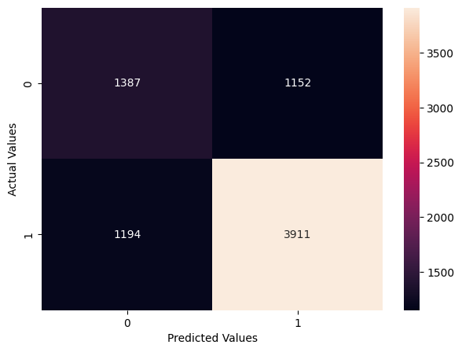

```
Result for the Testing model are:
```

|  | Recall | Precesion | Accuracy | F1_score |
| --- | --- | --- | --- | --- |
| 0 | 0.766112 | 0.772467 | 0.693093 | 0.769276 |

```python
# Evaluating testing model performance
bagging_estimator_test_perf = score(bagging_estimator,X_test,y_test,'Testing')
bagging_estimator_test_perf
```

**Bagging Hypertuned Model Building**

```python
# Choose the type of classifier.
bagging_estimator_tuned = BaggingClassifier(random_state=1)

# Grid of parameters to choose from
## add from article
parameters = {'max_samples': [0.8,0.9,1],
              'max_features': [0.7,0.8,0.9],
              'n_estimators' : [30,50,70]
             }

# Type of scoring used to compare parameter combinations
acc_scorer = metrics.make_scorer(metrics.f1_score)

# Run the grid search
grid_obj = GridSearchCV(bagging_estimator_tuned, parameters, scoring=acc_scorer,cv=5)
grid_obj = grid_obj.fit(X_train, y_train)

# Set the clf to the best combination of parameters
bagging_estimator_tuned = grid_obj.best_estimator_

# Fit the best algorithm to the data.
bagging_estimator_tuned.fit(X_train, y_train)
```

```
BaggingClassifier(max_features=0.7, max_samples=0.8, n_estimators=70,
                  random_state=1)
```

```
The precision score is 0.997
The recall score is 1.000
The accuracy score is 0.998
The F1 score is 0.999
```

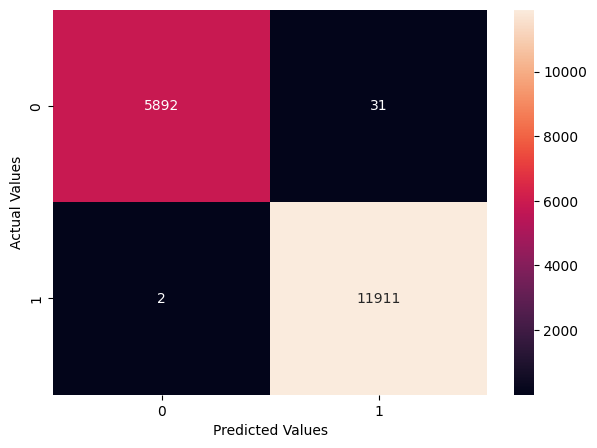

```
Result for the Training model are:
```

|  | Recall | Precesion | Accuracy | F1_score |
| --- | --- | --- | --- | --- |
| 0 | 0.999832 | 0.997404 | 0.99815 | 0.998617 |

```python
# Evaluating training model performance
bagging_estimator_tuned_train_perf = score(bagging_estimator_tuned,X_train,y_train,'Training')
bagging_estimator_tuned_train_perf
```

```
The precision score is 0.748
The recall score is 0.883
The accuracy score is 0.723
The F1 score is 0.810
```

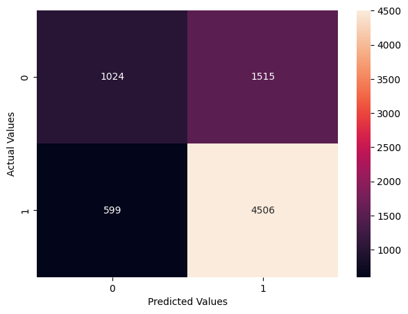

```
Result for the Testing model are:
```

|  | Recall | Precesion | Accuracy | F1_score |
| --- | --- | --- | --- | --- |
| 0 | 0.882664 | 0.748381 | 0.723443 | 0.809995 |

```python
# Evaluating training model performance
bagging_estimator_tuned_test_perf = score(bagging_estimator_tuned,X_test,y_test,'Testing')
bagging_estimator_tuned_test_perf
```

**Random Forest Classifier Model Building**

```python
#Train the random forest classifier
rf_estimator=RandomForestClassifier(random_state=1)
rf_estimator.fit(X_train,y_train)
```

```
RandomForestClassifier(random_state=1)
```

```
The precision score is 1.000
The recall score is 1.000
The accuracy score is 1.000
The F1 score is 1.000
```

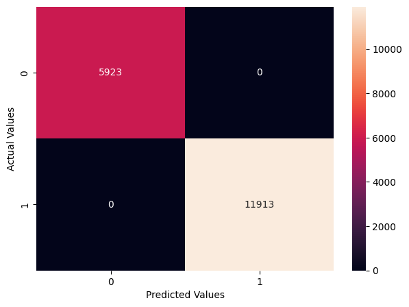

```
Result for the Training model are:
```

|  | Recall | Precesion | Accuracy | F1_score |
| --- | --- | --- | --- | --- |
| 0 | 1.0 | 1.0 | 1.0 | 1.0 |

```python
# Evaluating training model performance
rf_estimator_train_perf = score(rf_estimator,X_train,y_train,'Training')
rf_estimator_train_perf
```

```
The precision score is 0.767
The recall score is 0.837
The accuracy score is 0.722
The F1 score is 0.801
```

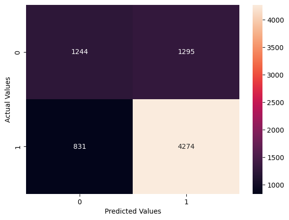

```
Result for the Testing model are:
```

|  | Recall | Precesion | Accuracy | F1_score |
| --- | --- | --- | --- | --- |
| 0 | 0.837218 | 0.767463 | 0.721873 | 0.800824 |

```python
# Evaluating testing model performance
rf_estimator_test_perf = score(rf_estimator,X_test,y_test,'Testing')
rf_estimator_test_perf
```

**Random Forest Classifier Hyper Tuining**

```python
# Choose the type of classifier.
rf_estimator_tuned = RandomForestClassifier(random_state=1)

# Grid of parameters to choose from
## add from article
parameters = {
    "class_weight": [{0: 0.5, 1: 0.5}],
    "n_estimators": [50,110,25],
    "min_samples_leaf": np.arange(1, 4),
    "max_features": [np.arange(0.3, 0.6, 0.1),'sqrt'],
    "max_samples": np.arange(0.4, 0.7, 0.1)
}

# Type of scoring used to compare parameter combinations
acc_scorer = metrics.make_scorer(metrics.f1_score)

# Run the grid search
grid_obj = GridSearchCV(rf_estimator_tuned, parameters, scoring=acc_scorer,cv=5)
grid_obj = grid_obj.fit(X_train, y_train)

# Set the clf to the best combination of parameters
rf_estimator_tuned = grid_obj.best_estimator_

# Fit the best algorithm to the data.
rf_estimator_tuned.fit(X_train, y_train)
```

```
RandomForestClassifier(class_weight={0: 0.5, 1: 0.5}, max_samples=0.4,
                       min_samples_leaf=3, n_estimators=110, random_state=1)
```

```
The precision score is 0.811
The recall score is 0.914
The accuracy score is 0.801
The F1 score is 0.860
```

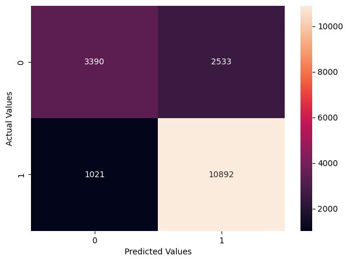

```
Result for the Training model are:
```

|  | Recall | Precesion | Accuracy | F1_score |
| --- | --- | --- | --- | --- |
| 0 | 0.914295 | 0.811322 | 0.80074 | 0.859736 |

```python
# Evaluating training model performance
rf_estimator_tuned_train_perf = score(rf_estimator_tuned,X_train,y_train,'Training')
rf_estimator_tuned_train_perf
```

```
The precision score is 0.769
The recall score is 0.873
The accuracy score is 0.740
The F1 score is 0.818
```

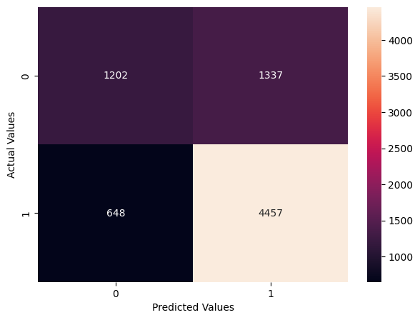

```
Result for the Testing model are:
```

|  | Recall | Precesion | Accuracy | F1_score |
| --- | --- | --- | --- | --- |
| 0 | 0.873066 | 0.769244 | 0.740319 | 0.817873 |

```python
# Evaluating testing model performance
rf_estimator_tuned_test_perf = score(rf_estimator_tuned,X_test,y_test,'Testing')
rf_estimator_tuned_test_perf
```

## **Boosting - Model Building and Hyperparameter Tuning**

**AdaBoost Classifier Model Building**

```python
abc = AdaBoostClassifier(random_state=1)
abc.fit(X_train,y_train)
```

```
AdaBoostClassifier(random_state=1)
```

```
The precision score is 0.759
The recall score is 0.888
The accuracy score is 0.737
The F1 score is 0.819
```

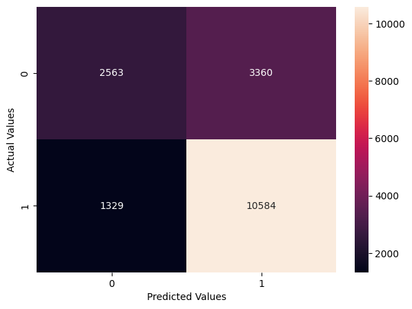

```
Result for the Training model are:
```

|  | Recall | Precesion | Accuracy | F1_score |
| --- | --- | --- | --- | --- |
| 0 | 0.888441 | 0.759036 | 0.737105 | 0.818656 |

```python
# Evaluating training model performance
abc_estimator_train_perf = score(abc,X_train,y_train,'Training')
abc_estimator_train_perf
```

```
The precision score is 0.755
The recall score is 0.885
The accuracy score is 0.732
The F1 score is 0.815
```

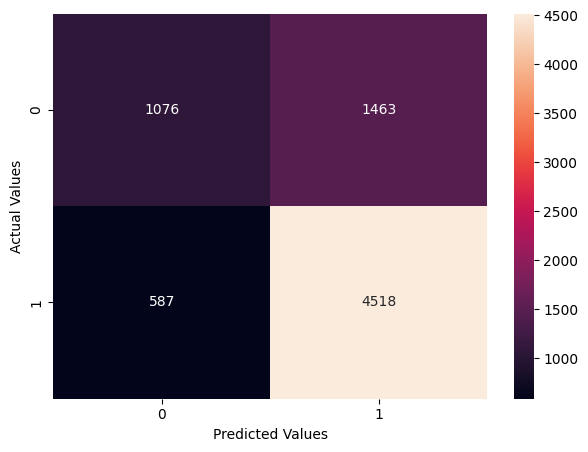

```
Result for the Testing model are:
```

|  | Recall | Precesion | Accuracy | F1_score |
| --- | --- | --- | --- | --- |
| 0 | 0.885015 | 0.755392 | 0.731816 | 0.815082 |

```python
# Evaluating testing model performance
abc_estimator_test_perf = score(abc,X_test,y_test,'Testing')
abc_estimator_test_perf
```

**AdaBoost Classifier Hypertuning**

```python
# Choose the type of classifier.
abc_tuned = AdaBoostClassifier(random_state=1)

# Grid of parameters to choose from
## add from article
parameters ={
    "n_estimators": np.arange(50,110,25),
    "learning_rate": [0.01,0.1,0.05],
    "base_estimator": [
        DecisionTreeClassifier(max_depth=2, random_state=1),
        DecisionTreeClassifier(max_depth=3, random_state=1),
    ],
}
# Type of scoring used to compare parameter combinations
acc_scorer = metrics.make_scorer(metrics.f1_score)

# Run the grid search
grid_obj = GridSearchCV(abc_tuned, parameters, scoring=acc_scorer,cv=5)
grid_obj = grid_obj.fit(X_train, y_train)

# Set the clf to the best combination of parameters
abc_tuned = grid_obj.best_estimator_

# Fit the best algorithm to the data.
abc_tuned.fit(X_train, y_train)
```

```
AdaBoostClassifier(base_estimator=DecisionTreeClassifier(max_depth=3,
                                                         random_state=1),
                   learning_rate=0.05, n_estimators=100, random_state=1)
```

```
The precision score is 0.777
The recall score is 0.885
The accuracy score is 0.753
The F1 score is 0.827
```

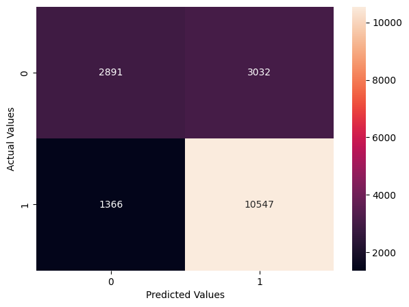

```
Result for the Training model are:
```

[output not shown]

```python
# Evaluating training model performance
abc_estimator_tuned_train_perf = score(abc_tuned,X_train,y_train,'Training')
abc_estimator_train_perf
```

```
The precision score is 0.769
The recall score is 0.879
The accuracy score is 0.743
The F1 score is 0.820
```

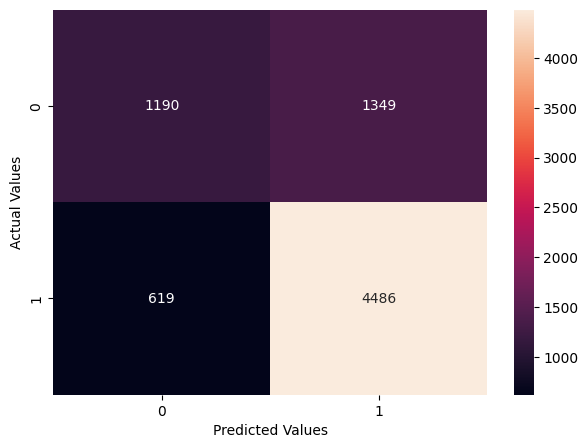

```
Result for the Testing model are:
```

|  | Recall | Precesion | Accuracy | F1_score |
| --- | --- | --- | --- | --- |
| 0 | 0.878746 | 0.768809 | 0.742543 | 0.82011 |

```python
# Evaluating testing model performance
abc_estimator_tuned_test_perf = score(abc_tuned,X_test,y_test,'Testing')
abc_estimator_tuned_test_perf
```

**Gradient Boosting Classifier Model Building**

```python
gbc_init = GradientBoostingClassifier(init=AdaBoostClassifier(random_state=1),random_state=1)
gbc_init.fit(X_train,y_train)
```

```
GradientBoostingClassifier(init=AdaBoostClassifier(random_state=1),
                           random_state=1)
```

```
The precision score is 0.783
The recall score is 0.881
The accuracy score is 0.757
The F1 score is 0.829
```

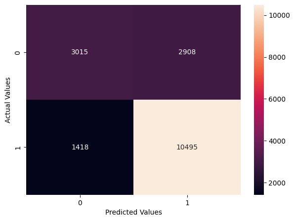

```
Result for the Training model are:
```

|  | Recall | Precesion | Accuracy | F1_score |
| --- | --- | --- | --- | --- |
| 0 | 0.88097 | 0.783034 | 0.757457 | 0.82912 |

```python
# Evaluating training model performance
gbc_estimator_train_perf = score(gbc_init,X_train,y_train,'Training')
gbc_estimator_train_perf
```

```
The precision score is 0.773
The recall score is 0.877
The accuracy score is 0.746
The F1 score is 0.822
```

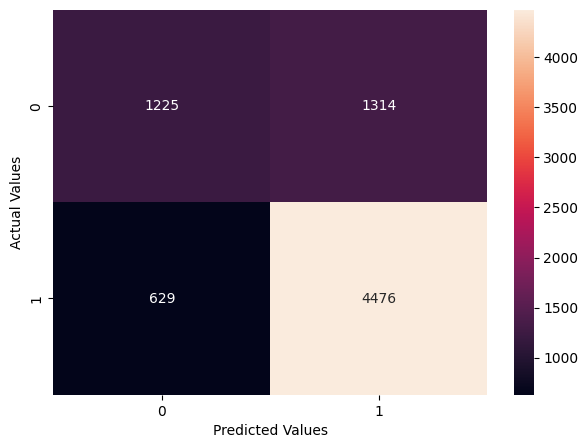

```
Result for the Testing model are:
```

|  | Recall | Precesion | Accuracy | F1_score |
| --- | --- | --- | --- | --- |
| 0 | 0.876787 | 0.773057 | 0.745814 | 0.821661 |

```python
# Evaluating training model performance
gbc_estimator_test_perf = score(gbc_init,X_test,y_test,'Testing')
gbc_estimator_test_perf
```

**Gradient Boosting Classifier Hypertuning**

```python
# Choose the type of classifier.
gbc_tuned = GradientBoostingClassifier(init=AdaBoostClassifier(random_state=1),random_state=1)

# Grid of parameters to choose from
## add from article
parameters = {
     "n_estimators": np.arange(50,110,25),
     "learning_rate": [0.01,0.1,0.05],
     "subsample":[0.7,0.9],
     "max_features":[0.5,0.7,1],
}

# Type of scoring used to compare parameter combinations
acc_scorer = metrics.make_scorer(metrics.f1_score)

# Run the grid search
grid_obj = GridSearchCV(gbc_tuned, parameters, scoring=acc_scorer,cv=5)
grid_obj = grid_obj.fit(X_train, y_train)

# Set the clf to the best combination of parameters
gbc_tuned = grid_obj.best_estimator_

# Fit the best algorithm to the data.
gbc_tuned.fit(X_train, y_train)
```

```
GradientBoostingClassifier(init=AdaBoostClassifier(random_state=1),
                           learning_rate=0.05, max_features=0.5,
                           n_estimators=75, random_state=1, subsample=0.7)
```

```
The precision score is 0.767
The recall score is 0.894
The accuracy score is 0.748
The F1 score is 0.826
```

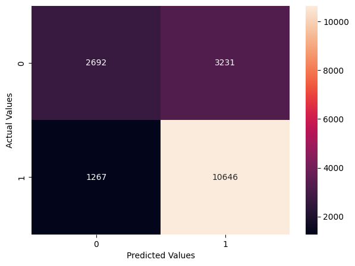

```
Result for the Training model are:
```

|  | Recall | Precesion | Accuracy | F1_score |
| --- | --- | --- | --- | --- |
| 0 | 0.893646 | 0.767169 | 0.747813 | 0.825591 |

```python
# Evaluating training model performance
gbc_estimator_tuned_train_perf = score(gbc_tuned,X_train,y_train,'Training')
gbc_estimator_tuned_train_perf
```

```
The precision score is 0.761
The recall score is 0.889
The accuracy score is 0.740
The F1 score is 0.820
```

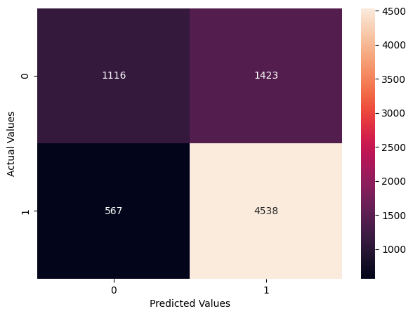

```
Result for the Testing model are:
```

|  | Recall | Precesion | Accuracy | F1_score |
| --- | --- | --- | --- | --- |
| 0 | 0.888932 | 0.761282 | 0.739665 | 0.82017 |

```python
# Evaluating training model performance
gbc_estimator_tuned_test_perf = score(gbc_tuned,X_test,y_test,'Testing')
gbc_estimator_tuned_test_perf
```

### **XGBoost Classifier**

```python
xgb = XGBClassifier(random_state=1,eval_metric='logloss')
xgb.fit(X_train,y_train)
```

```
XGBClassifier(base_score=None, booster=None, callbacks=None,
              colsample_bylevel=None, colsample_bynode=None,
              colsample_bytree=None, device=None, early_stopping_rounds=None,
              enable_categorical=False, eval_metric='logloss',
              feature_types=None, gamma=None, grow_policy=None,
              importance_type=None, interaction_constraints=None,
              learning_rate=None, max_bin=None, max_cat_threshold=None,
              max_cat_to_onehot=None, max_delta_step=None, max_depth=None,
              max_leaves=None, min_child_weight=None, missing=nan,
              monotone_constraints=None, multi_strategy=None, n_estimators=None,
              n_jobs=None, num_parallel_tree=None, random_state=1, ...)
```

```
The precision score is 0.849
The recall score is 0.931
The accuracy score is 0.843
The F1 score is 0.888
```

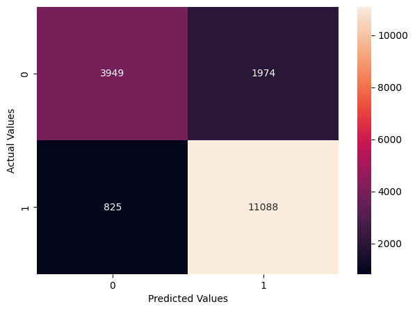

```
Result for the Training model are:
```

|  | Recall | Precesion | Accuracy | F1_score |
| --- | --- | --- | --- | --- |
| 0 | 0.930748 | 0.848875 | 0.84307 | 0.887928 |

```python
# Evaluating training model performance
xgb_estimator_train_perf = score(xgb,X_train,y_train,'Training')
xgb_estimator_train_perf
```

```
The precision score is 0.767
The recall score is 0.856
The accuracy score is 0.730
The F1 score is 0.809
```

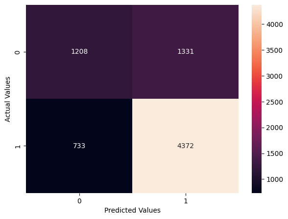

```
Result for the Testing model are:
```

|  | Recall | Precesion | Accuracy | F1_score |
| --- | --- | --- | --- | --- |
| 0 | 0.856415 | 0.766614 | 0.729984 | 0.80903 |

```python
# Evaluating training model performance
xgb_estimator_test_perf = score(xgb,X_test,y_test,'Testing')
xgb_estimator_test_perf
```

**XGBoost Classifier Hypertuning**

```python
# Choose the type of classifier.
xgb_tuned = XGBClassifier(random_state=1,eval_metric='logloss')

# Grid of parameters to choose from
## add from
parameters = {
            'n_estimators':np.arange(50,110,25),
            'scale_pos_weight':[1,2,5],
            'learning_rate':[0.01,0.1,0.05],
            'gamma':[1,3],
            'subsample':[0.7,0.9]
}

# Type of scoring used to compare parameter combinations
acc_scorer = metrics.make_scorer(metrics.f1_score)

# Run the grid search
grid_obj = GridSearchCV(xgb_tuned, parameters,scoring=acc_scorer,cv=5)
grid_obj = grid_obj.fit(X_train, y_train)

# Set the clf to the best combination of parameters
xgb_tuned = grid_obj.best_estimator_

# Fit the best algorithm to the data.
xgb_tuned.fit(X_train, y_train)
```

```
XGBClassifier(base_score=None, booster=None, callbacks=None,
              colsample_bylevel=None, colsample_bynode=None,
              colsample_bytree=None, device=None, early_stopping_rounds=None,
              enable_categorical=False, eval_metric='logloss',
              feature_types=None, gamma=3, grow_policy=None,
              importance_type=None, interaction_constraints=None,
              learning_rate=0.05, max_bin=None, max_cat_threshold=None,
              max_cat_to_onehot=None, max_delta_step=None, max_depth=None,
              max_leaves=None, min_child_weight=None, missing=nan,
              monotone_constraints=None, multi_strategy=None, n_estimators=50,
              n_jobs=None, num_parallel_tree=None, random_state=1, ...)
```

```
The precision score is 0.784
The recall score is 0.889
The accuracy score is 0.762
The F1 score is 0.833
```

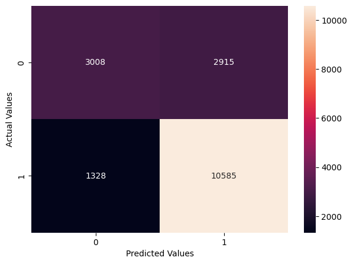

```
Result for the Training model are:
```

|  | Recall | Precesion | Accuracy | F1_score |
| --- | --- | --- | --- | --- |
| 0 | 0.888525 | 0.784074 | 0.76211 | 0.833038 |

```python
# Evaluating training model performance
xgb_estimator_tuned_train_perf = score(xgb_tuned,X_train,y_train,'Training')
xgb_estimator_tuned_train_perf
```

```
The precision score is 0.771
The recall score is 0.877
The accuracy score is 0.745
The F1 score is 0.821
```

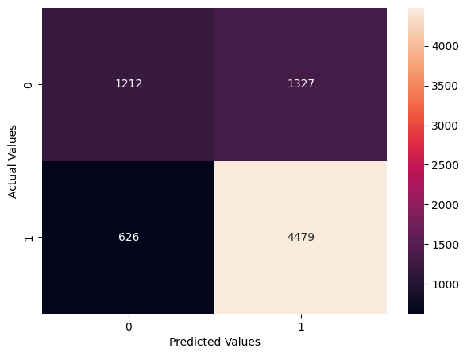

```
Result for the Testing model are:
```

|  | Recall | Precesion | Accuracy | F1_score |
| --- | --- | --- | --- | --- |
| 0 | 0.877375 | 0.771443 | 0.744505 | 0.821006 |

```python
# Evaluating testing model performance
xgb_estimator_tuned_test_perf = score(xgb_tuned,X_test,y_test,'Testing')
xgb_estimator_tuned_test_perf
```

## Model Performance Comparison and Conclusions

```python
# training performance comparison

models_train_comp_df = pd.concat(
    [
        decisiontree_train_perf.T,
        decisiontree_Hypertuned_train_perf.T,
        bagging_estimator_train_perf.T,
        bagging_estimator_tuned_train_perf.T,
        rf_estimator_train_perf.T,
        rf_estimator_tuned_train_perf.T,
        abc_estimator_train_perf.T,
        abc_estimator_tuned_train_perf.T,
        gbc_estimator_train_perf.T,
        gbc_estimator_tuned_train_perf.T,
        xgb_estimator_train_perf.T,
        xgb_estimator_tuned_train_perf.T,

    ],
    axis=1,
)
models_train_comp_df.columns = [
    "Decision Tree",
    "Tuned Decision Tree",
    "Bagging Classifier",
    "Tuned Bagging Classifier",
    "Random Forest",
    "Tuned Random Forest",
    "Adaboost Classifier",
    "Tuned Adaboost Classifier",
    "Gradient Boost Classifier",
    "Tuned Gradient Boost Classifier",
    "XGBoost Classifier",
    "XGBoost Classifier Tuned",

]
print("Training performance comparison:")
models_train_comp_df
```

```
Training performance comparison:
```

|  | Decision Tree | Tuned Decision Tree | Bagging Classifier | Tuned Bagging Classifier | Random Forest | Tuned Random Forest | Adaboost Classifier | Tuned Adaboost Classifier | Gradient Boost Classifier | Tuned Gradient Boost Classifier | XGBoost Classifier | XGBoost Classifier Tuned |
| --- | --- | --- | --- | --- | --- | --- | --- | --- | --- | --- | --- | --- |
| Recall | 1.0 | 0.778477 | 0.985142 | 0.999832 | 1.0 | 0.914295 | 0.888441 | 0.885335 | 0.880970 | 0.893646 | 0.930748 | 0.888525 |
| Precesion | 1.0 | 0.792853 | 0.990380 | 0.997404 | 1.0 | 0.811322 | 0.759036 | 0.776714 | 0.783034 | 0.767169 | 0.848875 | 0.784074 |
| Accuracy | 1.0 | 0.716192 | 0.983685 | 0.998150 | 1.0 | 0.800740 | 0.737105 | 0.753420 | 0.757457 | 0.747813 | 0.843070 | 0.762110 |
| F1_score | 1.0 | 0.785599 | 0.987754 | 0.998617 | 1.0 | 0.859736 | 0.818656 | 0.827475 | 0.829120 | 0.825591 | 0.887928 | 0.833038 |

```python
# testing performance comparison

models_test_comp_df = pd.concat(
    [
        decisiontree_test_perf.T,
        decisiontree_Hypertuned_test_perf.T,
        bagging_estimator_test_perf.T,
        bagging_estimator_tuned_test_perf.T,
        rf_estimator_test_perf.T,
        rf_estimator_tuned_test_perf.T,
        abc_estimator_test_perf.T,
        abc_estimator_tuned_test_perf.T,
        gbc_estimator_test_perf.T,
        gbc_estimator_tuned_test_perf.T,
        xgb_estimator_test_perf.T,
        xgb_estimator_tuned_test_perf.T,

    ],
    axis=1,
)
models_test_comp_df.columns = [
    "Decision Tree",
    "Tuned Decision Tree",
    "Bagging Classifier",
    "Tuned Bagging Classifier",
    "Random Forest",
    "Tuned Random Forest",
    "Adaboost Classifier",
    "Tuned Adaboost Classifier",
    "Gradient Boost Classifier",
    "Tuned Gradient Boost Classifier",
    "XGBoost Classifier",
    "XGBoost Classifier Tuned",

]
print("Testing performance comparison:")
models_test_comp_df
```

```
Testing performance comparison:
```

|  | Decision Tree | Tuned Decision Tree | Bagging Classifier | Tuned Bagging Classifier | Random Forest | Tuned Random Forest | Adaboost Classifier | Tuned Adaboost Classifier | Gradient Boost Classifier | Tuned Gradient Boost Classifier | XGBoost Classifier | XGBoost Classifier Tuned |
| --- | --- | --- | --- | --- | --- | --- | --- | --- | --- | --- | --- | --- |
| Recall | 0.739079 | 0.780803 | 0.766112 | 0.882664 | 0.837218 | 0.873066 | 0.885015 | 0.878746 | 0.876787 | 0.888932 | 0.856415 | 0.877375 |
| Precesion | 0.748908 | 0.789620 | 0.772467 | 0.748381 | 0.767463 | 0.769244 | 0.755392 | 0.768809 | 0.773057 | 0.761282 | 0.766614 | 0.771443 |
| Accuracy | 0.660256 | 0.714678 | 0.693093 | 0.723443 | 0.721873 | 0.740319 | 0.731816 | 0.742543 | 0.745814 | 0.739665 | 0.729984 | 0.744505 |
| F1_score | 0.743961 | 0.785187 | 0.769276 | 0.809995 | 0.800824 | 0.817873 | 0.815082 | 0.820110 | 0.821661 | 0.820170 | 0.809030 | 0.821006 |

**Model Performance Comparison and Conclusions Result**

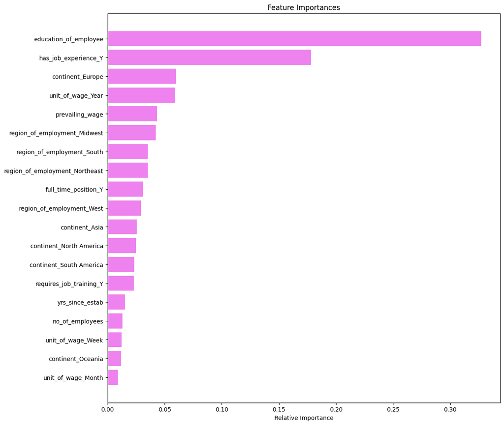

```python
feature_names = X_train.columns
importances = xgb_tuned.feature_importances_
indices = np.argsort(importances)

plt.figure(figsize=(12, 12))
plt.title("Feature Importances")
plt.barh(range(len(indices)), importances[indices], color="violet", align="center")
plt.yticks(range(len(indices)), [feature_names[i] for i in indices])
plt.xlabel("Relative Importance")
plt.show()
```

```python
# importance of features in the tree building ( The importance of a feature is computed as the
print (pd.DataFrame(xgb_tuned.feature_importances_, columns = ["Imp"], index = X_train.columns).sort_values(by = 'Imp', ascending = False))

#Here we will see that importance of features has increased
```

```
                                     Imp
education_of_employee           0.327159
has_job_experience_Y            0.178318
continent_Europe                0.060099
unit_of_wage_Year               0.059208
prevailing_wage                 0.043282
region_of_employment_Midwest    0.042286
region_of_employment_South      0.035259
region_of_employment_Northeast  0.035089
full_time_position_Y            0.031271
region_of_employment_West       0.029457
continent_Asia                  0.025658
continent_North America         0.024749
continent_South America         0.023583
requires_job_training_Y         0.023101
yrs_since_estab                 0.015157
no_of_employees                 0.012953
unit_of_wage_Week               0.012456
continent_Oceania               0.011986
unit_of_wage_Month              0.008930
```

As you can see feature education_of_employee and has_job_experience_Y are given almost 50% important for XGB tuned model.

## Actionable Insights and Recommendations

1. We were able to achieve 82.10% F1 score with Hypertuned XGB classifier model. We were able to get 87.74% Recall and 77.14% Precision score. Hypertuned XGB classifier model have given a generalized performance on the training and test set.
2. Education of the employee is very important feature for certifying or denying applicant visa application.Case status is in positive correlation with education_of_employee with factor of 0.32.Applicant with higher education degree has more chances of getting approval. Applicant with High school degree has only 34% chances of visa approval. Applicant with Bacheloers and Masters degree has 62.2% and 78.67% chances of getting approval respectively. Applicant with Phd has almost 87.22% of getting approval.
3. Applicants job experience is second best feature for certifying or denying applicant visa application. Applicant with job experience has 74.47% chances of certifying for the visa application while without job experience has only 56.13% chances of certifying. With work experience your chances of getting visa approval is high.
4. Applicant with prevailing wage unit Year has almost 70% chances of approval compared with Hour which has only 34.63% chances of approval.Applcation with prevailing wage in Months and Week has 61.79% and 62.13% chances of appproval.Almost 90% application has prevailing wage in Year followed by only 8.47% application has prevailing wage in Hour. There are less then 1% applications has unit of wage Month and Week.
5. Applicant from Europe has almost 79.23% chances of getting approval followed by Africa with 72.05%. Applicant from Asia has 65.31% chances of approval followed by 64% from Ocenia, 62% from North Ameirca and 58% from South America.Almost 66.17% application is from Asia followed by 14.65% from Europe, 12.92% from North America. Only 2.34% application are from Africa and 0.75% are from Ocenia.
6. Appplicant with region of employment Midwest has 75.52% chance of approval followed by applicant with South with 70%.Applicant with Northeast,West and Island region of employment has 62.9%,62.3% and 60.26% chances of approval. Almost 28.24% application is for Northeast region followed by 27.54% for South region,25% for West and 17% for Midwest region.Only 1.47% application is for Island region.
7. Prevailing wage mean for applicant whose case is approved or denied are almost similar for there unit of wage. So prevailing wage for applicant with Year as unit of wage is dollar 80746 for certified case status and dollar 82345 for denied case status.Case status is in positive correlation with Prevailing wage with factor of 0.07.
8. Most of the applicant are for full time position and it has 68.52% chances of approval compared with applicant without full time position has 66.58% chances of approval.
9. No of Employes and Years of establishment does not have much influence on Case status. Further more data and studies might be requiered to validate this.
10. Almost 91.45% of applicant with job experience does not need training compared with 84.17% applicant without job experience does not need training. Further more data and studies might be requiered to validate this.